# PART A: Box Plots

### 3.d.) y取倒數

```python
df_reciprocalBest = df_Best.copy()
df_reciprocalBest['cases'] = 1 / (df_reciprocalBest['cases'])
display(df_reciprocalBest)
```

|  | cases | Urban_pop_proportion | Expected_year_of_schooling | Mean_year_of_schooling | Nurse_midwife_per_1000_2009to18 | Physicians_per_1000_2009to18 | Specialist_surgical_workforce | HDI | GNI_per_capita |
| --- | --- | --- | --- | --- | --- | --- | --- | --- | --- |
| 0 | 0.000156 | 0.25 | 10.4 | 3.8 | 0.3 | 0.3 | 0.0 | 0.498 | 1824.0 |
| 1 | 0.001072 | 0.63 | 14.8 | 10.0 | 3.6 | 1.2 | 11.6 | 0.785 | 11886.0 |
| 2 | 0.000147 | 0.73 | 14.4 | 8.0 | 2.2 | 1.8 | 12.1 | 0.754 | 13802.0 |
| 6 | 0.000128 | 0.93 | 17.4 | 9.9 | 2.6 | 4.0 | 50.1 | 0.825 | 18461.0 |
| 7 | 0.000233 | 0.63 | 13.0 | 11.7 | 5.6 | 2.9 | 86.7 | 0.755 | 9144.0 |
| ... | ... | ... | ... | ... | ... | ... | ... | ... | ... |
| 187 | 0.002165 | 0.43 | 9.8 | 3.5 | 1.0 | 0.0 | 0.1 | 0.419 | 1240.0 |
| 188 | 0.015385 | 0.18 | 10.8 | 4.5 | 0.3 | 0.0 | 0.4 | 0.477 | 1064.0 |
| 191 | 0.008197 | 0.38 | 9.0 | 3.0 | 0.7 | 0.3 | 0.8 | 0.452 | 1239.0 |
| 193 | 0.000756 | 0.27 | 11.2 | 10.4 | 5.2 | 1.7 | 41.7 | 0.650 | 3317.0 |
| 194 | 1.000000 | 0.31 | 10.6 | 6.3 | 0.7 | 0.1 | 0.6 | 0.520 | 3255.0 |

109 rows × 9 columns

```python
result_reciprocalBest = smf.ols(
    'cases ~ Urban_pop_proportion + Expected_year_of_schooling + Mean_year_of_schooling + Nurse_midwife_per_1000_2009to18 + Physicians_per_1000_2009to18 + Specialist_surgical_workforce + HDI + GNI_per_capita',
    data=df_reciprocalBest).fit()
# Inspect the results
print(result_reciprocalBest.summary())
```

```
                            OLS Regression Results
==============================================================================
Dep. Variable:                  cases   R-squared:                       0.044
Model:                            OLS   Adj. R-squared:                 -0.033
Method:                 Least Squares   F-statistic:                    0.5714
Date:                Fri, 05 Jun 2020   Prob (F-statistic):              0.799
Time:                        02:32:38   Log-Likelihood:                 102.43
No. Observations:                 109   AIC:                            -186.9
Df Residuals:                     100   BIC:                            -162.6
Df Model:                           8
Covariance Type:            nonrobust
===================================================================================================
                                      coef    std err          t      P>|t|      [0.025      0.975]
---------------------------------------------------------------------------------------------------
Intercept                           0.0803      0.074      1.082      0.282      -0.067       0.227
Urban_pop_proportion               -0.0601      0.064     -0.934      0.352      -0.188       0.068
Expected_year_of_schooling          0.0063      0.009      0.689      0.493      -0.012       0.025
Mean_year_of_schooling              0.0090      0.008      1.111      0.269      -0.007       0.025
Nurse_midwife_per_1000_2009to18    -0.0020      0.006     -0.350      0.727      -0.013       0.009
Physicians_per_1000_2009to18       -0.0037      0.015     -0.256      0.799      -0.033       0.025
Specialist_surgical_workforce      -0.0002      0.001     -0.239      0.812      -0.001       0.001
HDI                                -0.2584      0.253     -1.023      0.309      -0.760       0.243
GNI_per_capita                   5.554e-07   1.07e-06      0.521      0.603   -1.56e-06    2.67e-06
==============================================================================
Omnibus:                      222.542   Durbin-Watson:                   1.133
Prob(Omnibus):                  0.000   Jarque-Bera (JB):            38373.876
Skew:                           9.266   Prob(JB):                         0.00
Kurtosis:                      93.033   Cond. No.                     4.82e+05
==============================================================================

Warnings:
[1] Standard Errors assume that the covariance matrix of the errors is correctly specified.
[2] The condition number is large, 4.82e+05. This might indicate that there are
strong multicollinearity or other numerical problems.
```

```
Columns in data are: ['Obs', 'Dep Var\nPopulation', 'Predicted\nValue', 'Std Error\nMean Predict', 'Mean ci\n95% low', 'Mean ci\n95% upp', 'Predict ci\n95% low', 'Predict ci\n95% upp', 'Residual', 'Std Error\nResidual', 'Student\nResidual', "Cook's\nD"]
```

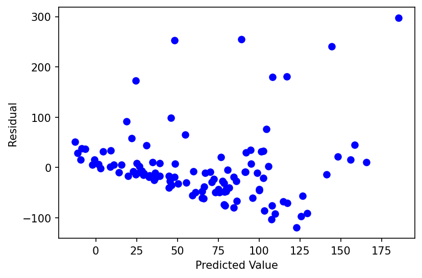

```python
st, data, ss2 = sso.summary_table(result_sqrtBest, alpha=0.05)
print("Columns in data are: %s" % ss2)
#Predicted value
x = data[:, 2]
#Residual
y = data[:, 8]
_ = plt.plot(x, y, 'o', color = 'b')
plt.xlabel('Predicted Value')
plt.ylabel('Residual')
plt.show()
```

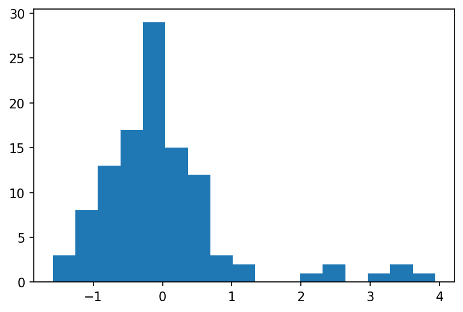

```python
_ = plt.hist(result_sqrtBest.resid_pearson, bins = 'auto')
```

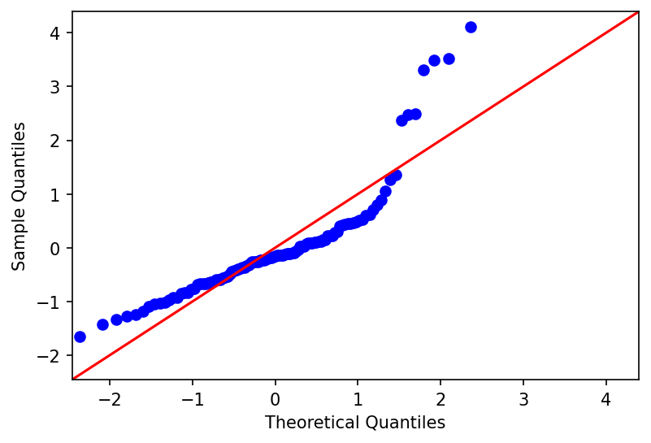

```python
fig = sm.qqplot(result_sqrtBest.resid_pearson, stats.norm, fit=True, line='45')
```

```python
stat, p = stats.shapiro(result_sqrtBest.resid_pearson)
print('Statistics=%.3f, p=%.3f' % (stat, p))
```

```
Statistics=0.811, p=0.000
```

## ------------------------------------ ！注意！------------------------------------

#### 以下這3陀: (對應結論.docx中的大標5.)

```
A. y取log,
B. y開根號,
C. y取倒數
```

#### 都是先對y值變換，再用forward selection找最好的解。

#### 而林昱辰她們原本的是先用forward selection，找出最好的解再對y變換，看normality的變化(對應結論.docx中的大標3.)

## ------------------------------------ ！注意！------------------------------------

### 5.A.) y取log

```python
# 對y做log變換

df_logBest = df_dropAll.copy()
df_logBest['cases'] = np.log(df_logBest['cases'])
#display(df_logBest)
```

```python
# forward selection

forward_selection(input_df = df_logBest,
                  depv = 'cases',
                  indepv = ['health_exp_per_capita', 'per_capita_exp_PPP_2016', 'Physicians_per_1000_2009to18', 'Nurse_midwife_per_1000_2009to18', 'Specialist_surgical_workforce', 'HDI', 'Life_Expectancy', 'Expected_year_of_schooling', 'Mean_year_of_schooling', 'GNI_per_capita', 'Latitude', 'Density', 'Med_age', 'Urban_pop_proportion', 'BCG'])
```

```
best_adjr2 =  0.3320104251972511
best_subset =  ['Urban_pop_proportion', 'Latitude', 'Density', 'BCG', 'Life_Expectancy', 'health_exp_per_capita', 'per_capita_exp_PPP_2016']
                            OLS Regression Results
==============================================================================
Dep. Variable:                  cases   R-squared:                       0.375
Model:                            OLS   Adj. R-squared:                  0.332
Method:                 Least Squares   F-statistic:                     8.668
Date:                Thu, 04 Jun 2020   Prob (F-statistic):           2.67e-08
Time:                        22:35:31   Log-Likelihood:                -225.99
No. Observations:                 109   AIC:                             468.0
Df Residuals:                     101   BIC:                             489.5
Df Model:                           7
Covariance Type:            nonrobust
===========================================================================================
                              coef    std err          t      P>|t|      [0.025      0.975]
-------------------------------------------------------------------------------------------
Intercept                   5.3975      2.635      2.049      0.043       0.171      10.624
Urban_pop_proportion        4.5401      1.351      3.361      0.001       1.860       7.220
Latitude                    0.0241      0.009      2.717      0.008       0.006       0.042
Density                     0.0018      0.001      1.933      0.056   -4.67e-05       0.004
BCG                        -0.0590      0.022     -2.642      0.010      -0.103      -0.015
Life_Expectancy             0.0547      0.042      1.302      0.196      -0.029       0.138
health_exp_per_capita      -0.0014      0.001     -1.787      0.077      -0.003       0.000
per_capita_exp_PPP_2016     0.0009      0.001      1.337      0.184      -0.000       0.002
==============================================================================
Omnibus:                        1.130   Durbin-Watson:                   1.994
Prob(Omnibus):                  0.568   Jarque-Bera (JB):                1.052
Skew:                          -0.061   Prob(JB):                        0.591
Kurtosis:                       2.534   Cond. No.                     1.97e+04
==============================================================================

Warnings:
[1] Standard Errors assume that the covariance matrix of the errors is correctly specified.
[2] The condition number is large, 1.97e+04. This might indicate that there are
strong multicollinearity or other numerical problems.
```

```python
result_logBest = smf.ols(
    'cases ~ Urban_pop_proportion + Latitude + Density + BCG + Life_Expectancy + health_exp_per_capita + per_capita_exp_PPP_2016',
    data=df_logBest).fit()
# Inspect the results
#print(result_logBest.summary())
```

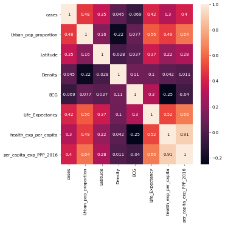

```python
# 觀察此 model的兩兩相交狀況

df_logg = df_logBest[['cases','Urban_pop_proportion','Latitude','Density','BCG','Life_Expectancy','health_exp_per_capita','per_capita_exp_PPP_2016']]
corr_log = df_logg.corr()
corr_log
plt.figure(figsize=(7, 7))

_ = sns.heatmap(corr_log, annot=True)
```

此model的兩兩相交狀況：只有兩個變數的correlation超過0.7

```python
stat, p = stats.shapiro(result_logBest.resid_pearson)
print('Statistics=%.3f, p=%.3f' % (stat, p))
```

```
Statistics=0.989, p=0.506
```

```
Columns in data are: ['Obs', 'Dep Var\nPopulation', 'Predicted\nValue', 'Std Error\nMean Predict', 'Mean ci\n95% low', 'Mean ci\n95% upp', 'Predict ci\n95% low', 'Predict ci\n95% upp', 'Residual', 'Std Error\nResidual', 'Student\nResidual', "Cook's\nD"]
```

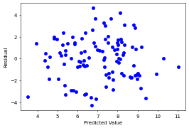

```python
st, data, ss2 = sso.summary_table(result_logBest, alpha=0.05)
print("Columns in data are: %s" % ss2)
#Predicted value
x = data[:, 2]
#Residual
y = data[:, 8]
_ = plt.plot(x, y, 'o', color = 'b')
plt.xlabel('Predicted Value')
plt.ylabel('Residual')
plt.show()
```

#### Checking residual normality (log-transformed marks)

To check the normality assumption, compute the residuals, plot histogram and Q-Q plot, and conduct Shapiro test.

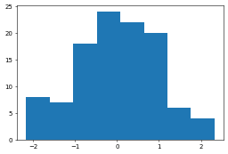

```python
_ = plt.hist(result_logBest.resid_pearson, bins = 'auto')
```

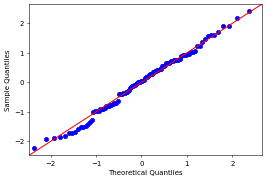

```python
fig = sm.qqplot(result_logBest.resid_pearson, stats.norm, fit=True, line='45')
```

```python
stat, p = stats.shapiro(result_logBest.resid_pearson)
print('Statistics=%.3f, p=%.3f' % (stat, p))
```

```
Statistics=0.989, p=0.506
```

normal了

### 5.B.) 開根號

```python
df_sqrtBest = df_dropAll.copy()
df_sqrtBest['cases'] = np.sqrt(df_sqrtBest['cases'])
#display(df_sqrtBest)
```

```python
forward_selection(input_df = df_sqrtBest,
                  depv = 'cases',
                  indepv = ['health_exp_per_capita', 'per_capita_exp_PPP_2016', 'Physicians_per_1000_2009to18', 'Nurse_midwife_per_1000_2009to18', 'Specialist_surgical_workforce', 'HDI', 'Life_Expectancy', 'Expected_year_of_schooling', 'Mean_year_of_schooling', 'GNI_per_capita', 'Latitude', 'Density', 'Med_age', 'Urban_pop_proportion', 'BCG'])
```

```
best_adjr2 =  0.21854147393246748
best_subset =  ['Urban_pop_proportion', 'Life_Expectancy', 'BCG', 'Physicians_per_1000_2009to18', 'Specialist_surgical_workforce', 'Density', 'Mean_year_of_schooling', 'HDI']
                            OLS Regression Results
==============================================================================
Dep. Variable:                  cases   R-squared:                       0.276
Model:                            OLS   Adj. R-squared:                  0.219
Method:                 Least Squares   F-statistic:                     4.775
Date:                Thu, 04 Jun 2020   Prob (F-statistic):           5.46e-05
Time:                        22:37:47   Log-Likelihood:                -620.65
No. Observations:                 109   AIC:                             1259.
Df Residuals:                     100   BIC:                             1284.
Df Model:                           8
Covariance Type:            nonrobust
=================================================================================================
                                    coef    std err          t      P>|t|      [0.025      0.975]
-------------------------------------------------------------------------------------------------
Intercept                       -52.7041    104.831     -0.503      0.616    -260.686     155.278
Urban_pop_proportion            121.0369     49.849      2.428      0.017      22.138     219.935
Life_Expectancy                  -0.1117      2.461     -0.045      0.964      -4.995       4.772
BCG                              -0.9395      0.707     -1.328      0.187      -2.343       0.464
Physicians_per_1000_2009to18    -22.8595     10.826     -2.112      0.037     -44.337      -1.382
Specialist_surgical_workforce     1.1539      0.472      2.447      0.016       0.218       2.089
Density                           0.0347      0.035      0.999      0.320      -0.034       0.104
Mean_year_of_schooling          -13.9449      6.698     -2.082      0.040     -27.233      -0.657
HDI                             378.1756    209.581      1.804      0.074     -37.627     793.979
==============================================================================
Omnibus:                       65.145   Durbin-Watson:                   1.936
Prob(Omnibus):                  0.000   Jarque-Bera (JB):              251.216
Skew:                           2.136   Prob(JB):                     2.81e-55
Kurtosis:                       9.087   Cond. No.                     8.19e+03
==============================================================================

Warnings:
[1] Standard Errors assume that the covariance matrix of the errors is correctly specified.
[2] The condition number is large, 8.19e+03. This might indicate that there are
strong multicollinearity or other numerical problems.
```

```python
result_sqrtBest = smf.ols(
    'cases ~ Urban_pop_proportion + Mean_year_of_schooling + Physicians_per_1000_2009to18 + Specialist_surgical_workforce + HDI + Density + BCG + Life_Expectancy',
    data=df_sqrtBest).fit()
# Inspect the results
#print(result_sqrtBest.summary())
```

adjusted r^2 increases to 0.219.

```
Columns in data are: ['Obs', 'Dep Var\nPopulation', 'Predicted\nValue', 'Std Error\nMean Predict', 'Mean ci\n95% low', 'Mean ci\n95% upp', 'Predict ci\n95% low', 'Predict ci\n95% upp', 'Residual', 'Std Error\nResidual', 'Student\nResidual', "Cook's\nD"]
```

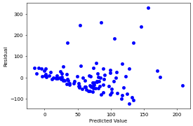

```python
st, data, ss2 = sso.summary_table(result_sqrtBest, alpha=0.05)
print("Columns in data are: %s" % ss2)
#Predicted value
x = data[:, 2]
#Residual
y = data[:, 8]
_ = plt.plot(x, y, 'o', color = 'b')
plt.xlabel('Predicted Value')
plt.ylabel('Residual')
plt.show()
```

#### Checking residual normality (log-transformed marks)

To check the normality assumption, compute the residuals, plot histogram and Q-Q plot, and conduct Shapiro test.

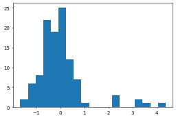

```python
_ = plt.hist(result_sqrtBest.resid_pearson, bins = 'auto')
```

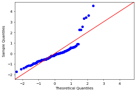

```python
fig = sm.qqplot(result_sqrtBest.resid_pearson, stats.norm, fit=True, line='45')
```

```python
stat, p = stats.shapiro(result_sqrtBest.resid_pearson)
print('Statistics=%.3f, p=%.3f' % (stat, p))
```

```
Statistics=0.800, p=0.000
```

不normal

### 5.C.) y取倒數(Reciprocal)

```python
df_reciprocalBest = df_dropAll.copy()
df_reciprocalBest['cases'] = 1 / (df_reciprocalBest['cases'])
#display(df_reciprocalBest)
```

```python
forward_selection(input_df = df_reciprocalBest,
                  depv = 'cases',
                  indepv = ['health_exp_per_capita', 'per_capita_exp_PPP_2016', 'Physicians_per_1000_2009to18', 'Nurse_midwife_per_1000_2009to18', 'Specialist_surgical_workforce', 'HDI', 'Life_Expectancy', 'Expected_year_of_schooling', 'Mean_year_of_schooling', 'GNI_per_capita', 'Latitude', 'Density', 'Med_age', 'Urban_pop_proportion', 'BCG'])
```

```
best_adjr2 =  0.11302005703329099
best_subset =  ['Latitude', 'Life_Expectancy', 'Med_age', 'Urban_pop_proportion', 'BCG', 'health_exp_per_capita']
                            OLS Regression Results
==============================================================================
Dep. Variable:                  cases   R-squared:                       0.162
Model:                            OLS   Adj. R-squared:                  0.113
Method:                 Least Squares   F-statistic:                     3.294
Date:                Thu, 04 Jun 2020   Prob (F-statistic):            0.00529
Time:                        22:39:06   Log-Likelihood:                 109.64
No. Observations:                 109   AIC:                            -205.3
Df Residuals:                     102   BIC:                            -186.4
Df Model:                           6
Covariance Type:            nonrobust
=========================================================================================
                            coef    std err          t      P>|t|      [0.025      0.975]
-----------------------------------------------------------------------------------------
Intercept                 0.2521      0.118      2.130      0.036       0.017       0.487
Latitude                 -0.0011      0.000     -2.464      0.015      -0.002      -0.000
Life_Expectancy          -0.0064      0.002     -2.981      0.004      -0.011      -0.002
Med_age                   0.0045      0.002      2.287      0.024       0.001       0.008
Urban_pop_proportion     -0.0654      0.054     -1.212      0.228      -0.172       0.042
BCG                       0.0014      0.001      1.442      0.152      -0.001       0.003
health_exp_per_capita  1.948e-05   1.75e-05      1.111      0.269   -1.53e-05    5.43e-05
==============================================================================
Omnibus:                      200.315   Durbin-Watson:                   1.121
Prob(Omnibus):                  0.000   Jarque-Bera (JB):            23397.118
Skew:                           7.670   Prob(JB):                         0.00
Kurtosis:                      73.116   Cond. No.                     1.12e+04
==============================================================================

Warnings:
[1] Standard Errors assume that the covariance matrix of the errors is correctly specified.
[2] The condition number is large, 1.12e+04. This might indicate that there are
strong multicollinearity or other numerical problems.
```

```python
result_reciprocalBest = smf.ols(
    'cases ~ Urban_pop_proportion + Latitude + Life_Expectancy + Med_age + BCG + health_exp_per_capita ',
    data=df_reciprocalBest).fit()
# Inspect the results
#print(result_reciprocalBest.summary())
```

```
Columns in data are: ['Obs', 'Dep Var\nPopulation', 'Predicted\nValue', 'Std Error\nMean Predict', 'Mean ci\n95% low', 'Mean ci\n95% upp', 'Predict ci\n95% low', 'Predict ci\n95% upp', 'Residual', 'Std Error\nResidual', 'Student\nResidual', "Cook's\nD"]
```

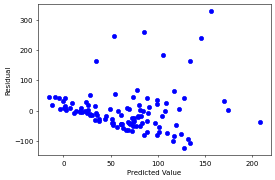

```python
st, data, ss2 = sso.summary_table(result_sqrtBest, alpha=0.05)
print("Columns in data are: %s" % ss2)
#Predicted value
x = data[:, 2]
#Residual
y = data[:, 8]
_ = plt.plot(x, y, 'o', color = 'b')
plt.xlabel('Predicted Value')
plt.ylabel('Residual')
plt.show()
```

#### Checking residual normality (log-transformed marks)

To check the normality assumption, compute the residuals, plot histogram and Q-Q plot, and conduct Shapiro test.

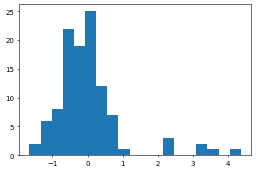

```python
_ = plt.hist(result_sqrtBest.resid_pearson, bins = 'auto')
```

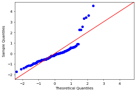

```python
fig = sm.qqplot(result_sqrtBest.resid_pearson, stats.norm, fit=True, line='45')
```

```python
stat, p = stats.shapiro(result_sqrtBest.resid_pearson)
print('Statistics=%.3f, p=%.3f' % (stat, p))
```

```
Statistics=0.800, p=0.000
```

不normal

## -------------------------------- 我是分隔線 --------------------------------

## 4. 增進 adjusted r^2 (對應結論.docx中的大標4.)

#### A.使用上面做出來的log best model(best std model只有係數有差)先把independent variables先standardlize再平方(立方/四方)。

```
a. 用上面forward做出來的best std model每個變數都standardlize再取2次,加上一次的變數一起跑forward
b. 用a.做出來的best std square model,加上(standardlize後的3次)變數跑forward
c. 用c.做出來的best std cubical model,加上(standardlize後的4次)變數跑forward
```

#### B. 用原始(一次)best std model, (y 為原始值)，加上兩兩變數的interaction,跑forward

#### C. 先對y取log變換，以4.b的data去跑forwad

## ---------------------------------------------------------------------------

```python
result_Best = smf.ols(
    'cases ~ Urban_pop_proportion + Expected_year_of_schooling + Mean_year_of_schooling + Nurse_midwife_per_1000_2009to18 + Physicians_per_1000_2009to18 + Specialist_surgical_workforce + HDI + GNI_per_capita',
    data=df_dropAll).fit()
# Inspect the results
print(result_Best.summary())
```

```
                            OLS Regression Results
==============================================================================
Dep. Variable:                  cases   R-squared:                       0.208
Model:                            OLS   Adj. R-squared:                  0.145
Method:                 Least Squares   F-statistic:                     3.290
Date:                Sun, 07 Jun 2020   Prob (F-statistic):            0.00225
Time:                        10:54:22   Log-Likelihood:                -1271.3
No. Observations:                 109   AIC:                             2561.
Df Residuals:                     100   BIC:                             2585.
Df Model:                           8
Covariance Type:            nonrobust
===================================================================================================
                                      coef    std err          t      P>|t|      [0.025      0.975]
---------------------------------------------------------------------------------------------------
Intercept                       -6.088e+04   2.21e+04     -2.759      0.007   -1.05e+05   -1.71e+04
Urban_pop_proportion             4.425e+04   1.91e+04      2.313      0.023    6287.701    8.22e+04
Expected_year_of_schooling       2364.8336   2740.371      0.863      0.390   -3071.985    7801.652
Mean_year_of_schooling          -7129.2948   2415.954     -2.951      0.004   -1.19e+04   -2336.110
Nurse_midwife_per_1000_2009to18  3156.5830   1710.710      1.845      0.068    -237.417    6550.583
Physicians_per_1000_2009to18    -9469.2867   4342.830     -2.180      0.032   -1.81e+04    -853.236
Specialist_surgical_workforce     286.2956    190.699      1.501      0.136     -92.046     664.637
HDI                               1.12e+05   7.52e+04      1.489      0.140   -3.72e+04    2.61e+05
GNI_per_capita                     -0.3412      0.317     -1.077      0.284      -0.970       0.287
==============================================================================
Omnibus:                      103.583   Durbin-Watson:                   1.974
Prob(Omnibus):                  0.000   Jarque-Bera (JB):             1038.590
Skew:                           3.274   Prob(JB):                    2.97e-226
Kurtosis:                      16.631   Cond. No.                     4.82e+05
==============================================================================

Warnings:
[1] Standard Errors assume that the covariance matrix of the errors is correctly specified.
[2] The condition number is large, 4.82e+05. This might indicate that there are
strong multicollinearity or other numerical problems.
```

### 4.A.a.)取2次

```python
df_square  = df_stdBest.copy()
df_square['cases'] = np.log(df_dropAll['cases'])

df_square['Urban_pop_proportion_std2'] = df_stdBest['Urban_pop_proportion_std'] ** 2
df_square['Expected_year_of_schooling_std2'] = df_stdBest['Expected_year_of_schooling_std'] ** 2
df_square['Mean_year_of_schooling_std2'] = df_stdBest['Mean_year_of_schooling_std'] ** 2
df_square['Nurse_midwife_per_1000_2009to18_std2'] = df_stdBest['Nurse_midwife_per_1000_2009to18_std'] ** 2
df_square['Physicians_per_1000_2009to18_std2'] = df_stdBest['Physicians_per_1000_2009to18_std'] ** 2
df_square['Specialist_surgical_workforce_std2'] = df_stdBest['Specialist_surgical_workforce_std'] ** 2
df_square['HDI_std2'] = df_stdBest['HDI_std'] ** 2
df_square['GNI_per_capita_std2'] = df_stdBest['GNI_per_capita_std'] ** 2


display(df_square)
```

|  | cases | health_exp_per_capita_std | per_capita_exp_PPP_2016_std | Physicians_per_1000_2009to18_std | Nurse_midwife_per_1000_2009to18_std | Specialist_surgical_workforce_std | HDI_std | Life_Expectancy_std | Expected_year_of_schooling_std | Mean_year_of_schooling_std | ... | Urban_pop_proportion_std | BCG_std | Urban_pop_proportion_std2 | Expected_year_of_schooling_std2 | Mean_year_of_schooling_std2 | Nurse_midwife_per_1000_2009to18_std2 | Physicians_per_1000_2009to18_std2 | Specialist_surgical_workforce_std2 | HDI_std2 | GNI_per_capita_std2 |
| --- | --- | --- | --- | --- | --- | --- | --- | --- | --- | --- | --- | --- | --- | --- | --- | --- | --- | --- | --- | --- | --- |
| 0 | 8.764366 | -0.475014 | -0.692407 | -0.719709 | -0.887187 | -0.790153 | -1.173740 | -0.812896 | -0.855108 | -1.290265 | ... | -1.382215 | -1.198881 | 1.910517 | 0.731209 | 1.664783 | 0.787100 | 0.517981 | 0.624342 | 1.377665 | 0.482867 |
| 1 | 6.838405 | -0.179942 | -0.032986 | -0.102546 | 0.268212 | -0.440228 | 0.865588 | 1.169487 | 0.896001 | 0.739439 | ... | 0.431833 | 0.717487 | 0.186479 | 0.802818 | 0.546771 | 0.071938 | 0.010516 | 0.193801 | 0.749243 | 0.001440 |
| 2 | 8.827761 | -0.195226 | 0.230495 | 0.308896 | -0.221957 | -0.425146 | 0.645312 | 0.868712 | 0.736809 | 0.084696 | ... | 0.909213 | 0.717487 | 0.826669 | 0.542888 | 0.007173 | 0.049265 | 0.095417 | 0.180749 | 0.416428 | 0.031506 |
| 6 | 8.962520 | 0.761452 | 0.819101 | 1.817517 | -0.081909 | 0.721159 | 1.149815 | 0.923398 | 1.930747 | 0.706702 | ... | 1.863975 | 0.169953 | 3.474403 | 3.727783 | 0.499428 | 0.006709 | 3.303367 | 0.520070 | 1.322075 | 0.267109 |
| 7 | 8.362409 | -0.059738 | 0.096490 | 1.063206 | 0.968453 | 1.825231 | 0.652418 | 0.663638 | 0.179638 | 1.295971 | ... | 0.431833 | 0.717487 | 0.186479 | 0.032270 | 1.679541 | 0.937902 | 1.130408 | 3.331468 | 0.425649 | 0.026164 |
| ... | ... | ... | ... | ... | ... | ... | ... | ... | ... | ... | ... | ... | ... | ... | ... | ... | ... | ... | ... | ... | ... |
| 187 | 6.135565 | -0.434946 | -0.602702 | -0.925430 | -0.642102 | -0.787136 | -1.735088 | -2.426147 | -1.093895 | -1.388476 | ... | -0.522929 | -0.103814 | 0.273455 | 1.196606 | 1.927866 | 0.412295 | 0.856421 | 0.619584 | 3.010531 | 0.543789 |
| 188 | 4.174387 | -0.513017 | -0.744992 | -0.925430 | -0.887187 | -0.778087 | -1.322959 | -0.853911 | -0.695916 | -1.061105 | ... | -1.716381 | 0.078698 | 2.945965 | 0.484299 | 1.125943 | 0.787100 | 0.856421 | 0.605419 | 1.750221 | 0.562859 |
| 191 | 4.804021 | -0.454636 | -0.712623 | -0.719709 | -0.747139 | -0.766020 | -1.500601 | -0.648837 | -1.412278 | -1.552162 | ... | -0.761620 | -2.476460 | 0.580064 | 1.994530 | 2.409207 | 0.558216 | 0.517981 | 0.586787 | 2.251803 | 0.543897 |
| 193 | 7.186901 | -0.477080 | -0.641920 | 0.240322 | 0.828405 | 0.467765 | -0.093678 | 0.171460 | -0.536724 | 0.870388 | ... | -1.286738 | 0.717487 | 1.655696 | 0.288073 | 0.757575 | 0.686255 | 0.057755 | 0.218804 | 0.008775 | 0.343569 |
| 194 | 0.000000 | -0.436048 | -0.604138 | -0.856856 | -0.747139 | -0.772053 | -1.017415 | -2.098028 | -0.775512 | -0.471836 | ... | -1.095786 | 0.626231 | 1.200747 | 0.601418 | 0.222629 | 0.558216 | 0.734203 | 0.596067 | 1.035133 | 0.348883 |

109 rows × 24 columns

```python
forward_selection(input_df = df_square,
                  depv = 'cases',
                  indepv = ['Urban_pop_proportion_std', 'Expected_year_of_schooling_std', 'Mean_year_of_schooling_std', 'Nurse_midwife_per_1000_2009to18_std', 'Physicians_per_1000_2009to18_std', 'Specialist_surgical_workforce_std', 'HDI_std', 'GNI_per_capita_std', 'Urban_pop_proportion_std2', 'Expected_year_of_schooling_std2', 'Mean_year_of_schooling_std2', 'Nurse_midwife_per_1000_2009to18_std2', 'Physicians_per_1000_2009to18_std2', 'Specialist_surgical_workforce_std2', 'HDI_std2', 'GNI_per_capita_std2'])
```

```
best_adjr2 =  0.3103828049970496
best_subset =  ['Urban_pop_proportion_std', 'Nurse_midwife_per_1000_2009to18_std2', 'HDI_std', 'Expected_year_of_schooling_std', 'Mean_year_of_schooling_std', 'Specialist_surgical_workforce_std', 'Physicians_per_1000_2009to18_std2', 'Mean_year_of_schooling_std2', 'Physicians_per_1000_2009to18_std', …
                            OLS Regression Results
==============================================================================
Dep. Variable:                  cases   R-squared:                       0.387
Model:                            OLS   Adj. R-squared:                  0.310
Method:                 Least Squares   F-statistic:                     5.051
Date:                Sun, 07 Jun 2020   Prob (F-statistic):           1.85e-06
Time:                        10:56:15   Log-Likelihood:                -224.96
No. Observations:                 109   AIC:                             475.9
Df Residuals:                      96   BIC:                             510.9
Df Model:                          12
Covariance Type:            nonrobust
========================================================================================================
                                           coef    std err          t      P>|t|      [0.025      0.975]
--------------------------------------------------------------------------------------------------------
Intercept                                7.3074      0.405     18.027      0.000       6.503       8.112
Urban_pop_proportion_std                 0.4916      0.293      1.680      0.096      -0.089       1.072
Nurse_midwife_per_1000_2009to18_std2     0.4181      0.202      2.074      0.041       0.018       0.818
HDI_std                                  1.4623      0.737      1.983      0.050      -0.002       2.926
Expected_year_of_schooling_std          -0.9297      0.479     -1.943      0.055      -1.880       0.020
Mean_year_of_schooling_std              -1.0277      0.520     -1.976      0.051      -2.060       0.005
Specialist_surgical_workforce_std        0.7502      0.464      1.615      0.110      -0.172       1.672
Physicians_per_1000_2009to18_std2       -0.3952      0.160     -2.473      0.015      -0.712      -0.078
Mean_year_of_schooling_std2             -0.5966      0.346     -1.722      0.088      -1.284       0.091
Physicians_per_1000_2009to18_std         1.2818      0.718      1.785      0.077      -0.144       2.707
HDI_std2                                 0.2750      0.311      0.883      0.379      -0.343       0.893
Nurse_midwife_per_1000_2009to18_std     -0.7409      0.554     -1.338      0.184      -1.840       0.359
GNI_per_capita_std2                      0.0449      0.044      1.024      0.308      -0.042       0.132
==============================================================================
Omnibus:                        1.630   Durbin-Watson:                   1.893
Prob(Omnibus):                  0.443   Jarque-Bera (JB):                1.113
Skew:                          -0.197   Prob(JB):                        0.573
Kurtosis:                       3.299   Cond. No.                         27.1
==============================================================================

Warnings:
[1] Standard Errors assume that the covariance matrix of the errors is correctly specified.
```

Nurse_midwife_per_1000_2009to18_std2, Physicians_per_1000_2009to18_std2 is significant.

Adj. R-squared: 0.310

```python
df_squareBest = df_square[['cases', 'Urban_pop_proportion_std', 'Nurse_midwife_per_1000_2009to18_std2', 'HDI_std', 'Expected_year_of_schooling_std', 'Mean_year_of_schooling_std', 'Specialist_surgical_workforce_std', 'Physicians_per_1000_2009to18_std2', 'Mean_year_of_schooling_std2', 'Physicians_per_1000_2009to18_std', 'HDI_std2', 'Nurse_midwife_per_1000_2009to18_std', 'GNI_per_capita_std2']]
```

```python
result_squareBest = smf.ols(
    'cases ~ Urban_pop_proportion_std + Nurse_midwife_per_1000_2009to18_std2 + HDI_std + Expected_year_of_schooling_std + Mean_year_of_schooling_std + Specialist_surgical_workforce_std + Physicians_per_1000_2009to18_std2 + Mean_year_of_schooling_std2 + Physicians_per_1000_2009to18_std + HDI_std2 + Nurse_midwife_per_1000_2009to18_std + GNI_per_capita_std2',
    data=df_squareBest).fit()
# Inspect the results
#print(result_squareBest.summary())
```

```
Columns in data are: ['Obs', 'Dep Var\nPopulation', 'Predicted\nValue', 'Std Error\nMean Predict', 'Mean ci\n95% low', 'Mean ci\n95% upp', 'Predict ci\n95% low', 'Predict ci\n95% upp', 'Residual', 'Std Error\nResidual', 'Student\nResidual', "Cook's\nD"]
```

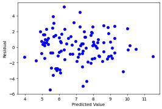

```python
st, data, ss2 = sso.summary_table(result_squareBest, alpha=0.05)
print("Columns in data are: %s" % ss2)
#Predicted value
x = data[:, 2]
#Residual
y = data[:, 8]
_ = plt.plot(x, y, 'o', color = 'b')
plt.xlabel('Predicted Value')
plt.ylabel('Residual')
plt.show()
```

#### Checking residual normality (log-transformed marks)

To check the normality assumption, compute the residuals, plot histogram and Q-Q plot, and conduct Shapiro test.

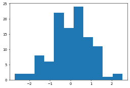

```python
_ = plt.hist(result_squareBest.resid_pearson, bins = 'auto')
```

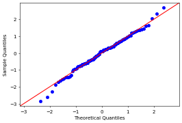

```python
fig = sm.qqplot(result_squareBest.resid_pearson, stats.norm, fit=True, line='45')
```

```python
stat, p = stats.shapiro(result_squareBest.resid_pearson)
print('Statistics=%.3f, p=%.3f' % (stat, p))
```

```
Statistics=0.993, p=0.840
```

normal

### 4.A.b.)取3次

```python
df_cube = df_squareBest.copy()

df_cube['Urban_pop_proportion_std3'] = df_stdBest['Urban_pop_proportion_std'] ** 3
df_cube['Expected_year_of_schooling_std3'] = df_stdBest['Expected_year_of_schooling_std'] ** 3
df_cube['Mean_year_of_schooling_std3'] = df_stdBest['Mean_year_of_schooling_std'] ** 3
df_cube['Nurse_midwife_per_1000_2009to18_std3'] = df_stdBest['Nurse_midwife_per_1000_2009to18_std'] ** 3
df_cube['Physicians_per_1000_2009to18_std3'] = df_stdBest['Physicians_per_1000_2009to18_std'] ** 3
df_cube['Specialist_surgical_workforce_std3'] = df_stdBest['Specialist_surgical_workforce_std'] ** 3
df_cube['HDI_std3'] = df_stdBest['HDI_std'] ** 3
df_cube['GNI_per_capita_std3'] = df_stdBest['GNI_per_capita_std'] ** 3


display(df_cube)
```

|  | cases | Urban_pop_proportion_std | Nurse_midwife_per_1000_2009to18_std2 | HDI_std | Expected_year_of_schooling_std | Mean_year_of_schooling_std | Specialist_surgical_workforce_std | Physicians_per_1000_2009to18_std2 | Mean_year_of_schooling_std2 | Physicians_per_1000_2009to18_std | ... | Nurse_midwife_per_1000_2009to18_std | GNI_per_capita_std2 | Urban_pop_proportion_std3 | Expected_year_of_schooling_std3 | Mean_year_of_schooling_std3 | Nurse_midwife_per_1000_2009to18_std3 | Physicians_per_1000_2009to18_std3 | Specialist_surgical_workforce_std3 | HDI_std3 | GNI_per_capita_std3 |
| --- | --- | --- | --- | --- | --- | --- | --- | --- | --- | --- | --- | --- | --- | --- | --- | --- | --- | --- | --- | --- | --- |
| 0 | 8.764366 | -1.382215 | 0.787100 | -1.173740 | -0.855108 | -1.290265 | -0.790153 | 0.517981 | 1.664783 | -0.719709 | ... | -0.887187 | 0.482867 | -2.640745 | -0.625262 | -2.148011 | -0.698305 | -0.372796 | -0.493326 | -1.617021 | -0.335538 |
| 1 | 6.838405 | 0.431833 | 0.071938 | 0.865588 | 0.896001 | 0.739439 | -0.440228 | 0.010516 | 0.546771 | -0.102546 | ... | 0.268212 | 0.001440 | 0.080528 | 0.719325 | 0.404304 | 0.019295 | -0.001078 | -0.085317 | 0.648536 | 0.000055 |
| 2 | 8.827761 | 0.909213 | 0.049265 | 0.645312 | 0.736809 | 0.084696 | -0.425146 | 0.095417 | 0.007173 | 0.308896 | ... | -0.221957 | 0.031506 | 0.751619 | 0.400005 | 0.000608 | -0.010935 | 0.029474 | -0.076845 | 0.268726 | 0.005592 |
| 6 | 8.962520 | 1.863975 | 0.006709 | 1.149815 | 1.930747 | 0.706702 | 0.721159 | 3.303367 | 0.499428 | 1.817517 | ... | -0.081909 | 0.267109 | 6.476201 | 7.197405 | 0.352947 | -0.000550 | 6.003926 | 0.375053 | 1.520142 | 0.138049 |
| 7 | 8.362409 | 0.431833 | 0.937902 | 0.652418 | 0.179638 | 1.295971 | 1.825231 | 1.130408 | 1.679541 | 1.063206 | ... | 0.968453 | 0.026164 | 0.080528 | 0.005797 | 2.176637 | 0.908314 | 1.201857 | 6.080699 | 0.277701 | -0.004232 |
| ... | ... | ... | ... | ... | ... | ... | ... | ... | ... | ... | ... | ... | ... | ... | ... | ... | ... | ... | ... | ... | ... |
| 187 | 6.135565 | -0.522929 | 0.412295 | -1.735088 | -1.093895 | -1.388476 | -0.787136 | 0.856421 | 1.927866 | -0.925430 | ... | -0.642102 | 0.543789 | -0.142998 | -1.308962 | -2.676796 | -0.264736 | -0.792557 | -0.487697 | -5.223536 | -0.401001 |
| 188 | 4.174387 | -1.716381 | 0.787100 | -1.322959 | -0.695916 | -1.061105 | -0.778087 | 0.856421 | 1.125943 | -0.925430 | ... | -0.887187 | 0.562859 | -5.056398 | -0.337031 | -1.194743 | -0.698305 | -0.792557 | -0.471068 | -2.315470 | -0.422279 |
| 191 | 4.804021 | -0.761620 | 0.558216 | -1.500601 | -1.412278 | -1.552162 | -0.766020 | 0.517981 | 2.409207 | -0.719709 | ... | -0.747139 | 0.543897 | -0.441788 | -2.816832 | -3.739479 | -0.417065 | -0.372796 | -0.449491 | -3.379057 | -0.401120 |
| 193 | 7.186901 | -1.286738 | 0.686255 | -0.093678 | -0.536724 | 0.870388 | 0.467765 | 0.057755 | 0.757575 | 0.240322 | ... | 0.828405 | 0.343569 | -2.130448 | -0.154616 | 0.659385 | 0.568497 | 0.013880 | 0.102349 | -0.000822 | -0.201382 |
| 194 | 0.000000 | -1.095786 | 0.558216 | -1.017415 | -0.775512 | -0.471836 | -0.772053 | 0.734203 | 0.222629 | -0.856856 | ... | -0.747139 | 0.348883 | -1.315762 | -0.466407 | -0.105044 | -0.417065 | -0.629106 | -0.460195 | -1.053160 | -0.206073 |

109 rows × 21 columns

```python
forward_selection(input_df = df_cube,
                  depv = 'cases',
                  indepv = ['Urban_pop_proportion_std', 'Nurse_midwife_per_1000_2009to18_std2', 'HDI_std', 'Expected_year_of_schooling_std', 'Mean_year_of_schooling_std', 'Specialist_surgical_workforce_std', 'Physicians_per_1000_2009to18_std2', 'Mean_year_of_schooling_std2', 'Physicians_per_1000_2009to18_std', 'HDI_std2', 'Nurse_midwife_per_1000_2009to18_std', 'GNI_per_capita_std2', 'Urban_pop_proportion_std3', 'Expected_year_of_schooling_std3', 'Mean_year_of_schooling_std3', 'Nurse_midwife_per_1000_2009to18_std3', 'Physicians_per_1000_2009to18_std3', 'Specialist_surgical_workforce_std3', 'HDI_std3', 'GNI_per_capita_std3'])
```

```
best_adjr2 =  0.3761140492839459
best_subset =  ['Urban_pop_proportion_std', 'Nurse_midwife_per_1000_2009to18_std2', 'Nurse_midwife_per_1000_2009to18_std3', 'HDI_std', 'Physicians_per_1000_2009to18_std2', 'Physicians_per_1000_2009to18_std3', 'Physicians_per_1000_2009to18_std', 'Mean_year_of_schooling_std', 'Nurse_midwife_per_1000_2…
                            OLS Regression Results
==============================================================================
Dep. Variable:                  cases   R-squared:                       0.457
Model:                            OLS   Adj. R-squared:                  0.376
Method:                 Least Squares   F-statistic:                     5.651
Date:                Sun, 07 Jun 2020   Prob (F-statistic):           8.39e-08
Time:                        10:56:34   Log-Likelihood:                -218.35
No. Observations:                 109   AIC:                             466.7
Df Residuals:                      94   BIC:                             507.1
Df Model:                          14
Covariance Type:            nonrobust
========================================================================================================
                                           coef    std err          t      P>|t|      [0.025      0.975]
--------------------------------------------------------------------------------------------------------
Intercept                                7.3747      0.506     14.568      0.000       6.370       8.380
Urban_pop_proportion_std                 0.5231      0.279      1.872      0.064      -0.032       1.078
Nurse_midwife_per_1000_2009to18_std2     1.3994      0.594      2.358      0.020       0.221       2.578
Nurse_midwife_per_1000_2009to18_std3    -0.2920      0.183     -1.597      0.114      -0.655       0.071
HDI_std                                  1.0182      0.760      1.340      0.183      -0.490       2.527
Physicians_per_1000_2009to18_std2       -1.6037      0.464     -3.454      0.001      -2.526      -0.682
Physicians_per_1000_2009to18_std3        0.2500      0.091      2.744      0.007       0.069       0.431
Physicians_per_1000_2009to18_std         1.6226      0.696      2.331      0.022       0.240       3.005
Mean_year_of_schooling_std              -1.0369      0.496     -2.090      0.039      -2.022      -0.052
Nurse_midwife_per_1000_2009to18_std     -0.9586      0.535     -1.792      0.076      -2.021       0.103
GNI_per_capita_std2                      0.0657      0.045      1.467      0.146      -0.023       0.155
Specialist_surgical_workforce_std        0.9192      0.482      1.908      0.059      -0.037       1.876
Mean_year_of_schooling_std2             -0.5208      0.330     -1.577      0.118      -1.177       0.135
Expected_year_of_schooling_std          -0.5594      0.471     -1.187      0.238      -1.495       0.376
HDI_std2                                 0.3437      0.305      1.128      0.262      -0.261       0.949
==============================================================================
Omnibus:                        3.124   Durbin-Watson:                   1.850
Prob(Omnibus):                  0.210   Jarque-Bera (JB):                2.845
Skew:                          -0.183   Prob(JB):                        0.241
Kurtosis:                       3.702   Cond. No.                         58.4
==============================================================================

Warnings:
[1] Standard Errors assume that the covariance matrix of the errors is correctly specified.
```

1)Nurse_midwife_per_1000_2009to18_std2,  
2)Physicians_per_1000_2009to18_std2,  
3)Physicians_per_1000_2009to18_std3,  
4)Physicians_per_1000_2009to18_std,  
5)Mean_year_of_schooling_std  
are significant.

Adj. R-squared: 0.376

```python
df_cubeBest = df_cube[['cases', 'Urban_pop_proportion_std', 'Nurse_midwife_per_1000_2009to18_std2', 'Nurse_midwife_per_1000_2009to18_std3', 'HDI_std', 'Physicians_per_1000_2009to18_std2', 'Physicians_per_1000_2009to18_std3', 'Physicians_per_1000_2009to18_std', 'Mean_year_of_schooling_std', 'Nurse_midwife_per_1000_2009to18_std', 'GNI_per_capita_std2', 'Specialist_surgical_workforce_std', 'Mean_year_of_schooling_std2', 'Expected_year_of_schooling_std', 'HDI_std2']]
```

```python
result_cubeBest = smf.ols(
    'cases ~ Urban_pop_proportion_std + Nurse_midwife_per_1000_2009to18_std2 + Nurse_midwife_per_1000_2009to18_std3 + HDI_std + Physicians_per_1000_2009to18_std2 + Physicians_per_1000_2009to18_std3 + Physicians_per_1000_2009to18_std + Mean_year_of_schooling_std + Nurse_midwife_per_1000_2009to18_std + GNI_per_capita_std2 + Specialist_surgical_workforce_std + Mean_year_of_schooling_std2 + Expected_year_of_schooling_std + HDI_std2',
    data=df_cubeBest).fit()
# Inspect the results
#print(result_cubeBest.summary())
```

```
Columns in data are: ['Obs', 'Dep Var\nPopulation', 'Predicted\nValue', 'Std Error\nMean Predict', 'Mean ci\n95% low', 'Mean ci\n95% upp', 'Predict ci\n95% low', 'Predict ci\n95% upp', 'Residual', 'Std Error\nResidual', 'Student\nResidual', "Cook's\nD"]
```

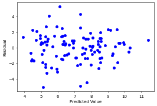

```python
st, data, ss2 = sso.summary_table(result_cubeBest, alpha=0.05)
print("Columns in data are: %s" % ss2)
#Predicted value
x = data[:, 2]
#Residual
y = data[:, 8]
_ = plt.plot(x, y, 'o', color = 'b')
plt.xlabel('Predicted Value')
plt.ylabel('Residual')
plt.show()
```

#### Checking residual normality (log-transformed marks)

To check the normality assumption, compute the residuals, plot histogram and Q-Q plot, and conduct Shapiro test.

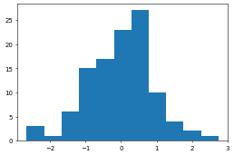

```python
_ = plt.hist(result_cubeBest.resid_pearson, bins = 'auto')
```

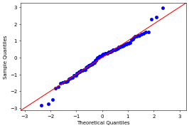

```python
fig = sm.qqplot(result_cubeBest.resid_pearson, stats.norm, fit=True, line='45')
```

```python
stat, p = stats.shapiro(result_cubeBest.resid_pearson)
print('Statistics=%.3f, p=%.3f' % (stat, p))
```

```
Statistics=0.984, p=0.205
```

normal

## outliers and influential observations

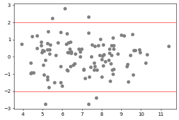

```python
st, data, ss2 = sso.summary_table(result_cubeBest, alpha=0.05)

#Predicted value
x = data[:, 2]
#Studentized Residual
y = data[:, 10]

plt.plot(x, y, 'o', color = 'gray')
plt.axhline(y=2, color = 'red', lw = 0.8)
plt.axhline(y=-2, color = 'red', lw = 0.8)
plt.show()
```

There are about six outliers in this model.

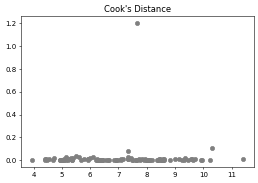

```python
x = data[:, 2]
cook_dist = data[:, 11]
plt.plot(x, cook_dist, 'o', color = 'gray')
plt.title("Cook's Distance")
plt.show()
```

```python
print(len(data[:,11]))
for i in range(len(data[:,11])):
    if data[i,11] > 1:
        print(data[i,11],i)
```

```
109
1.2030237479053634 28
```

```python
data[27,2]
```

[output not shown]

There exist an influential observation.

### 4.A.c.)取4次

```python
df_forth = df_cubeBest.copy()

df_forth['Urban_pop_proportion_std4'] = df_stdBest['Urban_pop_proportion_std'] ** 4
df_forth['Expected_year_of_schooling_std4'] = df_stdBest['Expected_year_of_schooling_std'] ** 4
df_forth['Mean_year_of_schooling_std4'] = df_stdBest['Mean_year_of_schooling_std'] ** 4
df_forth['Nurse_midwife_per_1000_2009to18_std4'] = df_stdBest['Nurse_midwife_per_1000_2009to18_std'] ** 4
df_forth['Physicians_per_1000_2009to18_std4'] = df_stdBest['Physicians_per_1000_2009to18_std'] ** 4
df_forth['Specialist_surgical_workforce_std4'] = df_stdBest['Specialist_surgical_workforce_std'] ** 4
df_forth['HDI_std4'] = df_stdBest['HDI_std'] ** 4


display(df_forth)
```

|  | cases | Urban_pop_proportion_std | Nurse_midwife_per_1000_2009to18_std2 | Nurse_midwife_per_1000_2009to18_std3 | HDI_std | Physicians_per_1000_2009to18_std2 | Physicians_per_1000_2009to18_std3 | Physicians_per_1000_2009to18_std | Mean_year_of_schooling_std | Nurse_midwife_per_1000_2009to18_std | ... | Mean_year_of_schooling_std2 | Expected_year_of_schooling_std | HDI_std2 | Urban_pop_proportion_std4 | Expected_year_of_schooling_std4 | Mean_year_of_schooling_std4 | Nurse_midwife_per_1000_2009to18_std4 | Physicians_per_1000_2009to18_std4 | Specialist_surgical_workforce_std4 | HDI_std4 |
| --- | --- | --- | --- | --- | --- | --- | --- | --- | --- | --- | --- | --- | --- | --- | --- | --- | --- | --- | --- | --- | --- |
| 0 | 8.764366 | -1.382215 | 0.787100 | -0.698305 | -1.173740 | 0.517981 | -0.372796 | -0.719709 | -1.290265 | -0.887187 | ... | 1.664783 | -0.855108 | 1.377665 | 3.650076 | 0.534667 | 2.771502 | 0.619527 | 0.268304 | 0.389803 | 1.897962 |
| 1 | 6.838405 | 0.431833 | 0.071938 | 0.019295 | 0.865588 | 0.010516 | -0.001078 | -0.102546 | 0.739439 | 0.268212 | ... | 0.546771 | 0.896001 | 0.749243 | 0.034775 | 0.644516 | 0.298958 | 0.005175 | 0.000111 | 0.037559 | 0.561365 |
| 2 | 8.827761 | 0.909213 | 0.049265 | -0.010935 | 0.645312 | 0.095417 | 0.029474 | 0.308896 | 0.084696 | -0.221957 | ... | 0.007173 | 0.736809 | 0.416428 | 0.683382 | 0.294727 | 0.000051 | 0.002427 | 0.009104 | 0.032670 | 0.173412 |
| 6 | 8.962520 | 1.863975 | 0.006709 | -0.000550 | 1.149815 | 3.303367 | 6.003926 | 1.817517 | 0.706702 | -0.081909 | ... | 0.499428 | 1.930747 | 1.322075 | 12.071478 | 13.896365 | 0.249428 | 0.000045 | 10.912237 | 0.270473 | 1.747883 |
| 7 | 8.362409 | 0.431833 | 0.937902 | 0.908314 | 0.652418 | 1.130408 | 1.201857 | 1.063206 | 1.295971 | 0.968453 | ... | 1.679541 | 0.179638 | 0.425649 | 0.034775 | 0.001041 | 2.820859 | 0.879660 | 1.277822 | 11.098681 | 0.181177 |
| ... | ... | ... | ... | ... | ... | ... | ... | ... | ... | ... | ... | ... | ... | ... | ... | ... | ... | ... | ... | ... | ... |
| 187 | 6.135565 | -0.522929 | 0.412295 | -0.264736 | -1.735088 | 0.856421 | -0.792557 | -0.925430 | -1.388476 | -0.642102 | ... | 1.927866 | -1.093895 | 3.010531 | 0.074778 | 1.431867 | 3.716667 | 0.169987 | 0.733456 | 0.383884 | 9.063295 |
| 188 | 4.174387 | -1.716381 | 0.787100 | -0.698305 | -1.322959 | 0.856421 | -0.792557 | -0.925430 | -1.061105 | -0.887187 | ... | 1.125943 | -0.695916 | 1.750221 | 8.678707 | 0.234545 | 1.267747 | 0.619527 | 0.733456 | 0.366532 | 3.063272 |
| 191 | 4.804021 | -0.761620 | 0.558216 | -0.417065 | -1.500601 | 0.517981 | -0.372796 | -0.719709 | -1.552162 | -0.747139 | ... | 2.409207 | -1.412278 | 2.251803 | 0.336475 | 3.978151 | 5.804277 | 0.311605 | 0.268304 | 0.344319 | 5.070616 |
| 193 | 7.186901 | -1.286738 | 0.686255 | 0.568497 | -0.093678 | 0.057755 | 0.013880 | 0.240322 | 0.870388 | 0.828405 | ... | 0.757575 | -0.536724 | 0.008775 | 2.741329 | 0.082986 | 0.573920 | 0.470946 | 0.003336 | 0.047875 | 0.000077 |
| 194 | 0.000000 | -1.095786 | 0.558216 | -0.417065 | -1.017415 | 0.734203 | -0.629106 | -0.856856 | -0.471836 | -0.747139 | ... | 0.222629 | -0.775512 | 1.035133 | 1.441794 | 0.361704 | 0.049564 | 0.311605 | 0.539054 | 0.355295 | 1.071501 |

109 rows × 22 columns

```python
# ['Urban_pop_proportion_std', 'Specialist_surgical_workforce_std', 'Specialist_surgical_workforce_std3', 'Mean_year_of_schooling_std3', 'Nurse_midwife_per_1000_2009to18_std3', 'HDI_std3', 'Expected_year_of_schooling_std', 'Physicians_per_1000_2009to18_std2', 'Physicians_per_1000_2009to18_std', 'Physicians_per_1000_2009to18_std3', 'Specialist_surgical_workforce_std2', 'Nurse_midwife_per_1000_2009to18_std', 'GNI_per_capita_std3', 'Nurse_midwife_per_1000_2009to18_std2']
```

```python
# 'Urban_pop_proportion_std4', 'Expected_year_of_schooling_std4', 'Mean_year_of_schooling_std4', 'Nurse_midwife_per_1000_2009to18_std4', 'Physicians_per_1000_2009to18_std4', 'Specialist_surgical_workforce_std4', 'HDI_std4'
```

```python
forward_selection(input_df = df_forth,
                  depv = 'cases',
                  indepv = ['Urban_pop_proportion_std', 'Nurse_midwife_per_1000_2009to18_std2', 'Nurse_midwife_per_1000_2009to18_std3', 'HDI_std', 'Physicians_per_1000_2009to18_std2', 'Physicians_per_1000_2009to18_std3', 'Physicians_per_1000_2009to18_std', 'Mean_year_of_schooling_std', 'Nurse_midwife_per_1000_2009to18_std', 'GNI_per_capita_std2', 'Specialist_surgical_workforce_std', 'Mean_year_of_schooling_std2', 'Expected_year_of_schooling_std', 'HDI_std2', 'Urban_pop_proportion_std4', 'Expected_year_of_schooling_std4', 'Mean_year_of_schooling_std4', 'Nurse_midwife_per_1000_2009to18_std4', 'Physicians_per_1000_2009to18_std4', 'Specialist_surgical_workforce_std4', 'HDI_std4'])
```

```
best_adjr2 =  0.3743512121305387
best_subset =  ['Urban_pop_proportion_std', 'Nurse_midwife_per_1000_2009to18_std2', 'Nurse_midwife_per_1000_2009to18_std3', 'HDI_std', 'Physicians_per_1000_2009to18_std2', 'Physicians_per_1000_2009to18_std3', 'Physicians_per_1000_2009to18_std4', 'Mean_year_of_schooling_std', 'Specialist_surgical_wor…
                            OLS Regression Results
==============================================================================
Dep. Variable:                  cases   R-squared:                       0.455
Model:                            OLS   Adj. R-squared:                  0.374
Method:                 Least Squares   F-statistic:                     5.616
Date:                Fri, 05 Jun 2020   Prob (F-statistic):           9.40e-08
Time:                        17:15:31   Log-Likelihood:                -218.51
No. Observations:                 109   AIC:                             467.0
Df Residuals:                      94   BIC:                             507.4
Df Model:                          14
Covariance Type:            nonrobust
========================================================================================================
                                           coef    std err          t      P>|t|      [0.025      0.975]
--------------------------------------------------------------------------------------------------------
Intercept                                7.7248      0.558     13.848      0.000       6.617       8.832
Urban_pop_proportion_std                 0.6263      0.272      2.304      0.023       0.087       1.166
Nurse_midwife_per_1000_2009to18_std2     1.7323      0.612      2.829      0.006       0.517       2.948
Nurse_midwife_per_1000_2009to18_std3    -0.3999      0.198     -2.024      0.046      -0.792      -0.008
HDI_std                                  0.1387      0.599      0.231      0.817      -1.051       1.328
Physicians_per_1000_2009to18_std2       -1.9758      0.681     -2.899      0.005      -3.329      -0.623
Physicians_per_1000_2009to18_std3        0.5645      0.504      1.119      0.266      -0.437       1.566
Physicians_per_1000_2009to18_std4       -0.0489      0.079     -0.616      0.540      -0.207       0.109
Mean_year_of_schooling_std              -0.7564      0.507     -1.493      0.139      -1.762       0.250
Specialist_surgical_workforce_std        0.7875      0.480      1.642      0.104      -0.165       1.740
GNI_per_capita_std2                      0.0833      0.043      1.930      0.057      -0.002       0.169
Nurse_midwife_per_1000_2009to18_std     -0.8315      0.572     -1.454      0.149      -1.967       0.304
Physicians_per_1000_2009to18_std         1.3808      0.841      1.642      0.104      -0.289       3.051
Mean_year_of_schooling_std2             -1.0551      0.662     -1.595      0.114      -2.369       0.259
Mean_year_of_schooling_std4              0.2633      0.195      1.347      0.181      -0.125       0.651
==============================================================================
Omnibus:                        3.036   Durbin-Watson:                   1.742
Prob(Omnibus):                  0.219   Jarque-Bera (JB):                2.511
Skew:                          -0.246   Prob(JB):                        0.285
Kurtosis:                       3.558   Cond. No.                         272.
==============================================================================

Warnings:
[1] Standard Errors assume that the covariance matrix of the errors is correctly specified.
```

```python
df_forthBest = df_forth[['cases', 'Urban_pop_proportion_std', 'Nurse_midwife_per_1000_2009to18_std2', 'Nurse_midwife_per_1000_2009to18_std3', 'HDI_std', 'Physicians_per_1000_2009to18_std2', 'Physicians_per_1000_2009to18_std3', 'Physicians_per_1000_2009to18_std4', 'Mean_year_of_schooling_std', 'Specialist_surgical_workforce_std', 'GNI_per_capita_std2', 'Nurse_midwife_per_1000_2009to18_std', 'Physicians_per_1000_2009to18_std', 'Mean_year_of_schooling_std2', 'Mean_year_of_schooling_std4']]
```

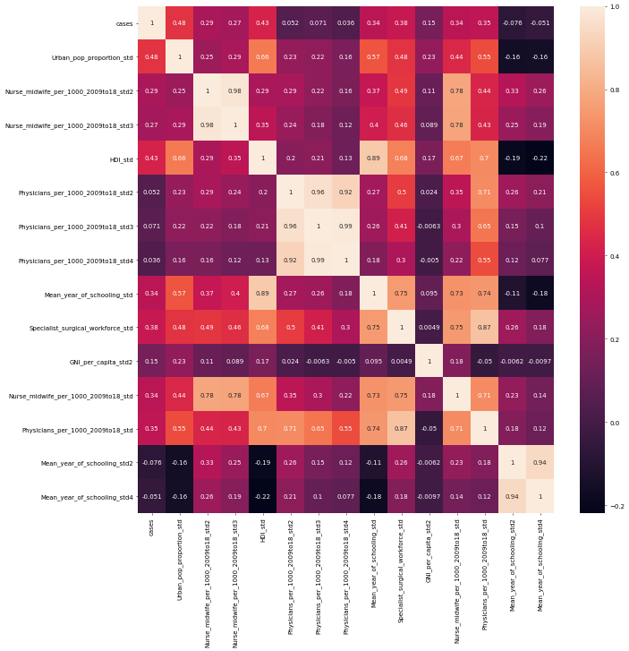

```python
corr_fb = df_forthBest.corr()
corr_fb
plt.figure(figsize=(15, 15))

_ = sns.heatmap(corr_fb, annot=True)
```

```python
result_forthBest = smf.ols(
    'cases ~ Urban_pop_proportion_std + Nurse_midwife_per_1000_2009to18_std2 + Nurse_midwife_per_1000_2009to18_std3 + HDI_std + Physicians_per_1000_2009to18_std2 + Physicians_per_1000_2009to18_std3 + Physicians_per_1000_2009to18_std4 + Mean_year_of_schooling_std + Specialist_surgical_workforce_std + GNI_per_capita_std2 + Nurse_midwife_per_1000_2009to18_std + Physicians_per_1000_2009to18_std + Mean_year_of_schooling_std2 + Mean_year_of_schooling_std4',
    data=df_forthBest).fit()
# Inspect the results
#print(result_forthBest.summary())
```

```
Columns in data are: ['Obs', 'Dep Var\nPopulation', 'Predicted\nValue', 'Std Error\nMean Predict', 'Mean ci\n95% low', 'Mean ci\n95% upp', 'Predict ci\n95% low', 'Predict ci\n95% upp', 'Residual', 'Std Error\nResidual', 'Student\nResidual', "Cook's\nD"]
```

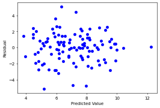

```python
st, data, ss2 = sso.summary_table(result_forthBest, alpha=0.05)
print("Columns in data are: %s" % ss2)
#Predicted value
x = data[:, 2]
#Residual
y = data[:, 8]
_ = plt.plot(x, y, 'o', color = 'b')
plt.xlabel('Predicted Value')
plt.ylabel('Residual')
plt.show()
```

#### Checking residual normality (log-transformed marks)

To check the normality assumption, compute the residuals, plot histogram and Q-Q plot, and conduct Shapiro test.

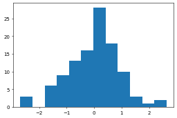

```python
_ = plt.hist(result_forthBest.resid_pearson, bins = 'auto')
```

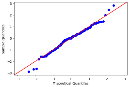

```python
fig = sm.qqplot(result_forthBest.resid_pearson, stats.norm, fit=True, line='45')
```

```python
stat, p = stats.shapiro(result_forthBest.resid_pearson)
print('Statistics=%.3f, p=%.3f' % (stat, p))
```

```
Statistics=0.985, p=0.257
```

normal

### 4.B.) With interaction(y不取log)

```python
df_interac = df_stdBest.copy()
#df_interac['cases'] = np.log(df_interac['cases'])

df_interac['Urban_Expected'] = df_stdBest['Urban_pop_proportion_std'] * df_stdBest['Expected_year_of_schooling_std']
df_interac['Urban_Mean'] = df_stdBest['Urban_pop_proportion_std'] * df_stdBest['Mean_year_of_schooling_std']
df_interac['Urban_Nurse'] = df_stdBest['Urban_pop_proportion_std'] * df_stdBest['Nurse_midwife_per_1000_2009to18_std']
df_interac['Urban_Physicians'] = df_stdBest['Urban_pop_proportion_std'] * df_stdBest['Physicians_per_1000_2009to18_std']
df_interac['Urban_Specialist'] = df_stdBest['Urban_pop_proportion_std'] * df_stdBest['Specialist_surgical_workforce_std']
df_interac['Urban_HDI'] = df_stdBest['Urban_pop_proportion_std'] * df_stdBest['HDI_std']
df_interac['Urban_GNI'] = df_stdBest['Urban_pop_proportion_std'] * df_stdBest['GNI_per_capita_std']

df_interac['Expected_Mean'] = df_stdBest['Expected_year_of_schooling_std'] * df_stdBest['Mean_year_of_schooling_std']
df_interac['Expected_Nurse'] = df_stdBest['Expected_year_of_schooling_std'] * df_stdBest['Nurse_midwife_per_1000_2009to18_std']
df_interac['Expected_Physicians'] = df_stdBest['Expected_year_of_schooling_std'] * df_stdBest['Physicians_per_1000_2009to18_std']
df_interac['Expected_Specialist'] = df_stdBest['Expected_year_of_schooling_std'] * df_stdBest['Specialist_surgical_workforce_std']
df_interac['Expected_HDI'] = df_stdBest['Expected_year_of_schooling_std'] * df_stdBest['HDI_std']
df_interac['Expected_GNI'] = df_stdBest['Expected_year_of_schooling_std'] * df_stdBest['GNI_per_capita_std']


df_interac['Mean_Nurse'] = df_stdBest['Mean_year_of_schooling_std'] * df_stdBest['Nurse_midwife_per_1000_2009to18_std']
df_interac['Mean_Physicians'] = df_stdBest['Mean_year_of_schooling_std'] * df_stdBest['Physicians_per_1000_2009to18_std']
df_interac['Mean_Specialist'] = df_stdBest['Mean_year_of_schooling_std'] * df_stdBest['Specialist_surgical_workforce_std']
df_interac['Mean_HDI'] = df_stdBest['Mean_year_of_schooling_std'] * df_stdBest['HDI_std']
df_interac['Mean_GNI'] = df_stdBest['Mean_year_of_schooling_std'] * df_stdBest['GNI_per_capita_std']

df_interac['Nurse_Pysicians'] = df_stdBest['Nurse_midwife_per_1000_2009to18_std'] * df_stdBest['Physicians_per_1000_2009to18_std']
df_interac['Nurse_Specialists'] = df_stdBest['Nurse_midwife_per_1000_2009to18_std'] * df_stdBest['Specialist_surgical_workforce_std']
df_interac['Nurse_HDI'] = df_stdBest['Nurse_midwife_per_1000_2009to18_std'] * df_stdBest['HDI_std']
df_interac['Nurse_GNI'] = df_stdBest['Nurse_midwife_per_1000_2009to18_std'] * df_stdBest['GNI_per_capita_std']

df_interac['Physicians_Specialist'] = df_stdBest['Physicians_per_1000_2009to18_std'] * df_stdBest['Specialist_surgical_workforce_std']
df_interac['Physicians_HDI'] = df_stdBest['Physicians_per_1000_2009to18_std'] * df_stdBest['HDI_std']
df_interac['Physicians_GNI'] = df_stdBest['Physicians_per_1000_2009to18_std'] * df_stdBest['GNI_per_capita_std']

df_interac['Specialist_HDI'] = df_stdBest['Specialist_surgical_workforce_std'] * df_stdBest['HDI_std']
df_interac['Specialist_GNI'] = df_stdBest['Specialist_surgical_workforce_std'] * df_stdBest['GNI_per_capita_std']

df_interac['HDI_GNI'] = df_stdBest['HDI_std'] * df_stdBest['GNI_per_capita_std']

display(df_interac)
```

|  | cases | health_exp_per_capita_std | per_capita_exp_PPP_2016_std | Physicians_per_1000_2009to18_std | Nurse_midwife_per_1000_2009to18_std | Specialist_surgical_workforce_std | HDI_std | Life_Expectancy_std | Expected_year_of_schooling_std | Mean_year_of_schooling_std | ... | Nurse_Pysicians | Nurse_Specialists | Nurse_HDI | Nurse_GNI | Physicians_Specialist | Physicians_HDI | Physicians_GNI | Specialist_HDI | Specialist_GNI | HDI_GNI |
| --- | --- | --- | --- | --- | --- | --- | --- | --- | --- | --- | --- | --- | --- | --- | --- | --- | --- | --- | --- | --- | --- |
| 0 | 6402 | -0.475014 | -0.692407 | -0.719709 | -0.887187 | -0.790153 | -1.173740 | -0.812896 | -0.855108 | -1.290265 | ... | 0.638516 | 0.701013 | 1.041327 | 0.616494 | 0.568680 | 0.844751 | 0.500116 | 0.927434 | 0.549067 | 0.815616 |
| 1 | 933 | -0.179942 | -0.032986 | -0.102546 | 0.268212 | -0.440228 | 0.865588 | 1.169487 | 0.896001 | 0.739439 | ... | -0.027504 | -0.118074 | 0.232161 | 0.010179 | 0.045144 | -0.088763 | -0.003892 | -0.381057 | -0.016708 | 0.032852 |
| 2 | 6821 | -0.195226 | 0.230495 | 0.308896 | -0.221957 | -0.425146 | 0.645312 | 0.868712 | 0.736809 | 0.084696 | ... | -0.068562 | 0.094364 | -0.143232 | -0.039397 | -0.131326 | 0.199334 | 0.054829 | -0.274352 | -0.075463 | 0.114543 |
| 6 | 7805 | 0.761452 | 0.819101 | 1.817517 | -0.081909 | 0.721159 | 1.149815 | 0.923398 | 1.930747 | 0.706702 | ... | -0.148871 | -0.059069 | -0.094180 | -0.042333 | 1.310718 | 2.089809 | 0.939340 | 0.829199 | 0.372714 | 0.594255 |
| 7 | 4283 | -0.059738 | 0.096490 | 1.063206 | 0.968453 | 1.825231 | 0.652418 | 0.663638 | 0.179638 | 1.295971 | ... | 1.029666 | 1.767651 | 0.631837 | -0.156651 | 1.940597 | 0.693655 | -0.171977 | 1.190814 | -0.295237 | -0.105531 |
| ... | ... | ... | ... | ... | ... | ... | ... | ... | ... | ... | ... | ... | ... | ... | ... | ... | ... | ... | ... | ... | ... |
| 187 | 462 | -0.434946 | -0.602702 | -0.925430 | -0.642102 | -0.787136 | -1.735088 | -2.426147 | -1.093895 | -1.388476 | ... | 0.594221 | 0.505422 | 1.114104 | 0.473500 | 0.728440 | 1.605703 | 0.682431 | 1.365751 | 0.580451 | 1.279490 |
| 188 | 65 | -0.513017 | -0.744992 | -0.925430 | -0.887187 | -0.778087 | -1.322959 | -0.853911 | -0.695916 | -1.061105 | ... | 0.821029 | 0.690308 | 1.173712 | 0.665602 | 0.720065 | 1.224306 | 0.694294 | 1.029377 | 0.583751 | 0.992536 |
| 191 | 122 | -0.454636 | -0.712623 | -0.719709 | -0.747139 | -0.766020 | -1.500601 | -0.648837 | -1.412278 | -1.552162 | ... | 0.537722 | 0.572323 | 1.121157 | 0.551010 | 0.551312 | 1.079996 | 0.530781 | 1.149491 | 0.564935 | 1.106683 |
| 193 | 1322 | -0.477080 | -0.641920 | 0.240322 | 0.828405 | 0.467765 | -0.093678 | 0.171460 | -0.536724 | 0.870388 | ... | 0.199084 | 0.387499 | -0.077603 | -0.485568 | 0.112414 | -0.022513 | -0.140864 | -0.043819 | -0.274180 | 0.054909 |
| 194 | 1 | -0.436048 | -0.604138 | -0.856856 | -0.747139 | -0.772053 | -1.017415 | -2.098028 | -0.775512 | -0.471836 | ... | 0.640190 | 0.576831 | 0.760150 | 0.441307 | 0.661539 | 0.871779 | 0.506114 | 0.785499 | 0.456024 | 0.600950 |

109 rows × 44 columns

```python
forward_selection(input_df = df_interac,
                  depv = 'cases',
                  indepv = ['Urban_pop_proportion_std', 'Expected_year_of_schooling_std', 'Mean_year_of_schooling_std', 'Nurse_midwife_per_1000_2009to18_std', 'Physicians_per_1000_2009to18_std', 'Specialist_surgical_workforce_std', 'HDI_std', 'GNI_per_capita_std', 'Urban_Expected', 'Urban_Mean', 'Urban_Nurse', 'Urban_Physicians', 'Urban_Specialist', 'Urban_HDI', 'Urban_GNI', 'Expected_Mean', 'Expected_Nurse', 'Expected_Physicians', 'Expected_Specialist', 'Expected_HDI', 'Expected_GNI', 'Mean_Nurse', 'Mean_Physicians', 'Mean_Specialist', 'Mean_HDI', 'Mean_GNI', 'Nurse_Pysicians', 'Nurse_Specialists', 'Nurse_HDI', 'Nurse_GNI', 'Physicians_Specialist', 'Physicians_HDI', 'Physicians_GNI', 'Specialist_HDI', 'Specialist_GNI', 'HDI_GNI'])
```

```
best_adjr2 =  0.5223362555062538
best_subset =  ['Urban_pop_proportion_std', 'Urban_Nurse', 'Mean_Nurse', 'Nurse_midwife_per_1000_2009to18_std', 'Mean_year_of_schooling_std', 'Specialist_surgical_workforce_std', 'Mean_Specialist', 'Urban_Physicians', 'Nurse_GNI', 'Expected_GNI', 'Expected_Mean', 'Urban_GNI', 'Expected_year_of_schoo…
                            OLS Regression Results
==============================================================================
Dep. Variable:                  cases   R-squared:                       0.606
Model:                            OLS   Adj. R-squared:                  0.522
Method:                 Least Squares   F-statistic:                     7.216
Date:                Thu, 04 Jun 2020   Prob (F-statistic):           3.12e-11
Time:                        23:01:12   Log-Likelihood:                -1233.3
No. Observations:                 109   AIC:                             2507.
Df Residuals:                      89   BIC:                             2560.
Df Model:                          19
Covariance Type:            nonrobust
=======================================================================================================
                                          coef    std err          t      P>|t|      [0.025      0.975]
-------------------------------------------------------------------------------------------------------
Intercept                            2.692e+04   4460.863      6.034      0.000    1.81e+04    3.58e+04
Urban_pop_proportion_std             6869.9259   3310.360      2.075      0.041     292.311    1.34e+04
Urban_Nurse                          1.681e+04   6478.055      2.595      0.011    3940.998    2.97e+04
Mean_Nurse                          -2748.5329   8451.329     -0.325      0.746   -1.95e+04     1.4e+04
Nurse_midwife_per_1000_2009to18_std  3663.7531   7018.592      0.522      0.603   -1.03e+04    1.76e+04
Mean_year_of_schooling_std              -3e+04   5810.441     -5.164      0.000   -4.15e+04   -1.85e+04
Specialist_surgical_workforce_std    3.122e+04   7874.051      3.965      0.000    1.56e+04    4.69e+04
Mean_Specialist                     -3.702e+04   1.06e+04     -3.478      0.001   -5.82e+04   -1.59e+04
Urban_Physicians                    -2.341e+04   4682.475     -5.000      0.000   -3.27e+04   -1.41e+04
Nurse_GNI                           -2.608e+04   6925.437     -3.766      0.000   -3.98e+04   -1.23e+04
Expected_GNI                         3.664e+04   1.02e+04      3.574      0.001    1.63e+04     5.7e+04
Expected_Mean                       -1.938e+04   8440.644     -2.296      0.024   -3.62e+04   -2607.339
Urban_GNI                            1.802e+04   7910.622      2.278      0.025    2303.552    3.37e+04
Expected_year_of_schooling_std       1.246e+04   5301.036      2.351      0.021    1929.672     2.3e+04
Physicians_Specialist                1.506e+04   6452.800      2.334      0.022    2242.206    2.79e+04
Expected_Nurse                       1.851e+04   9046.115      2.046      0.044     533.458    3.65e+04
HDI_GNI                             -2.139e+04   1.41e+04     -1.513      0.134   -4.95e+04    6696.664
Mean_HDI                             1.411e+04   9572.240      1.474      0.144   -4914.121    3.31e+04
Nurse_Pysicians                     -9272.0465   6841.259     -1.355      0.179   -2.29e+04    4321.390
Urban_Specialist                     8441.0316   7429.665      1.136      0.259   -6321.555    2.32e+04
==============================================================================
Omnibus:                       51.315   Durbin-Watson:                   1.782
Prob(Omnibus):                  0.000   Jarque-Bera (JB):              192.250
Skew:                           1.597   Prob(JB):                     1.79e-42
Kurtosis:                       8.668   Cond. No.                         37.8
==============================================================================

Warnings:
[1] Standard Errors assume that the covariance matrix of the errors is correctly specified.
```

Adj. R-squared: 0.52

best_subset = ['Urban_pop_proportion_std', 'Urban_Nurse', 'Mean_Nurse', 'Nurse_midwife_per_1000_2009to18_std', 'Mean_year_of_schooling_std', 'Specialist_surgical_workforce_std', 'Mean_Specialist', 'Urban_Physicians', 'Nurse_GNI', 'Expected_GNI', 'Expected_Mean', 'Urban_GNI', 'Expected_year_of_schooling_std', 'Physicians_Specialist', 'Expected_Nurse', 'HDI_GNI', 'Mean_HDI', 'Nurse_Pysicians', 'Urban_Specialist']

```python
df_interacBest = df_interac[['cases', 'Urban_pop_proportion_std', 'Urban_Nurse', 'Mean_Nurse', 'Nurse_midwife_per_1000_2009to18_std', 'Mean_year_of_schooling_std', 'Specialist_surgical_workforce_std', 'Mean_Specialist', 'Urban_Physicians', 'Nurse_GNI', 'Expected_GNI', 'Expected_Mean', 'Urban_GNI', 'Expected_year_of_schooling_std', 'Physicians_Specialist', 'Expected_Nurse', 'HDI_GNI', 'Mean_HDI', 'Nurse_Pysicians', 'Urban_Specialist']]
```

```python
result_interacBest = smf.ols(
    'cases ~ Urban_pop_proportion_std + Urban_Nurse + Mean_Nurse + Nurse_midwife_per_1000_2009to18_std + Mean_year_of_schooling_std + Specialist_surgical_workforce_std + Mean_Specialist + Urban_Physicians + Nurse_GNI + Expected_GNI + Expected_Mean + Urban_GNI + Expected_year_of_schooling_std + Physicians_Specialist + Expected_Nurse + HDI_GNI + Mean_HDI + Nurse_Pysicians + Urban_Specialist',
    data=df_interacBest).fit()
# Inspect the results
#print(result_interacBest.summary())
```

```
Columns in data are: ['Obs', 'Dep Var\nPopulation', 'Predicted\nValue', 'Std Error\nMean Predict', 'Mean ci\n95% low', 'Mean ci\n95% upp', 'Predict ci\n95% low', 'Predict ci\n95% upp', 'Residual', 'Std Error\nResidual', 'Student\nResidual', "Cook's\nD"]
```

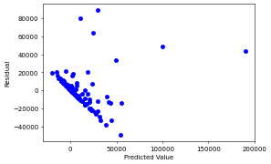

```python
st, data, ss2 = sso.summary_table(result_interacBest, alpha=0.05)
print("Columns in data are: %s" % ss2)
#Predicted value
x = data[:, 2]
#Residual
y = data[:, 8]
_ = plt.plot(x, y, 'o', color = 'b')
plt.xlabel('Predicted Value')
plt.ylabel('Residual')
plt.show()
```

#### Checking residual normality (log-transformed marks)

To check the normality assumption, compute the residuals, plot histogram and Q-Q plot, and conduct Shapiro test.

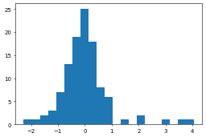

```python
_ = plt.hist(result_interacBest.resid_pearson, bins = 'auto')
```

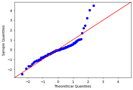

```python
fig = sm.qqplot(result_interacBest.resid_pearson, stats.norm, fit=True, line='45')
```

```python
stat, p = stats.shapiro(result_interacBest.resid_pearson)
print('Statistics=%.3f, p=%.3f' % (stat, p))
```

```
Statistics=0.866, p=0.000
```

不 normal